# EDA Assignment 8

Motoki Sugino

11/18/2016

### 1. Exploring Football Scores

The dataset football in the LearnEDA package gives the number of points scored by the winning team (team1) and the losing team (team2) for a large number of American football games.

```r
library(LearnEDA)
head(football)
```

```
##   winner loser
## 1     50     0
## 2      0     0
## 3     55     0
## 4     24     3
## 5     28    20
## 6      8     7
```

#### (a) Using the bin boundaries -0.5, 6.5, 13.5, 20.5, 27.5, 34.5, 41.5, 48.5, 55.5, 62.5, 69.5, 76.5 , have R construct a histogram of the scores of the winning team (variable team1).

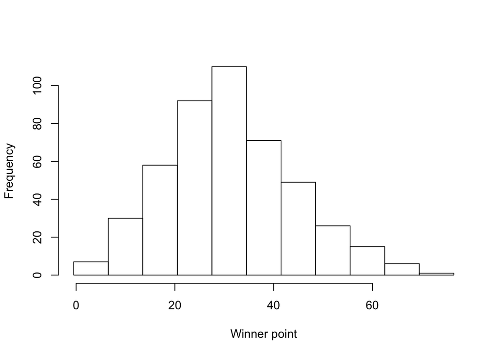

```r
bins <- c(-0.5, 6.5, 13.5, 20.5, 27.5, 34.5, 41.5, 48.5, 55.5, 62.5, 69.5, 76.5)
bin.mids <- (bins[-1] + bins[-length(bins)]) / 2
h <- with(football,hist(winner, breaks = bins, xlab = "Winner point", main = ""))
```

The first thing that we should notice is the approximate bell-shape of the times. Most of the Winner point have distributed in the 20-40 and it pretty uncommon to have a winner point close to 0 or larger than 60.

```r
data.frame(Mid=h$mids, Count=h$counts, Roots=sqrt(h$counts))
```

```
##    Mid Count     Roots
## 1    3     7  2.645751
## 2   10    30  5.477226
## 3   17    58  7.615773
## 4   24    92  9.591663
## 5   31   110 10.488088
## 6   38    71  8.426150
## 7   45    49  7.000000
## 8   52    26  5.099020
## 9   59    15  3.872983
## 10  66     6  2.449490
## 11  73     1  1.000000
```

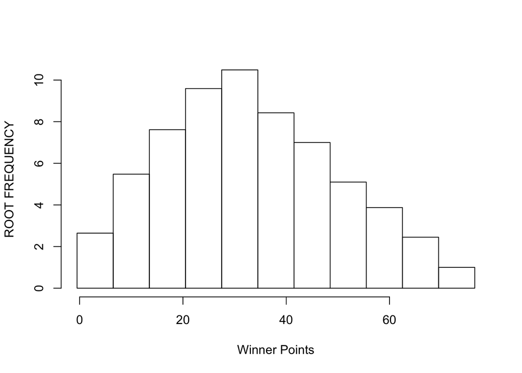

```r
h$counts <- sqrt(h$counts)
plot(h, xlab = "Winner Points", ylab = "ROOT FREQUENCY", main = "")
```

There is a right skewed. By taking a root reexpression, the the variability of the heights of the bars is approximately the same for small and large counts. So we are ready to make comparisons between the observed counts and fitted counts from a Gaussian curve.

#### (b) Fit a Gaussian comparison curve to these data. Use R to compute and display the raw residuals (RawRes) and the double root residuals (DRRes) for all bins of the data.

```r
#We find the Gaussian mean by taking the average of the lower and upper fourths:
summary(bins)
```

```
##    Min. 1st Qu.  Median    Mean 3rd Qu.    Max.
##   -0.50   18.75   38.00   38.00   57.25   76.50
```

```r
g.mean=(lval(football$winner)[2,3]+lval(football$winner)[2,2])/2
g.mean
```

```
## [1] 30
```

```r
g.sd=(lval(football$winner)[2,3]-lval(football$winner)[2,2])/1.349
g.sd
```

```
## [1] 13.34322
```

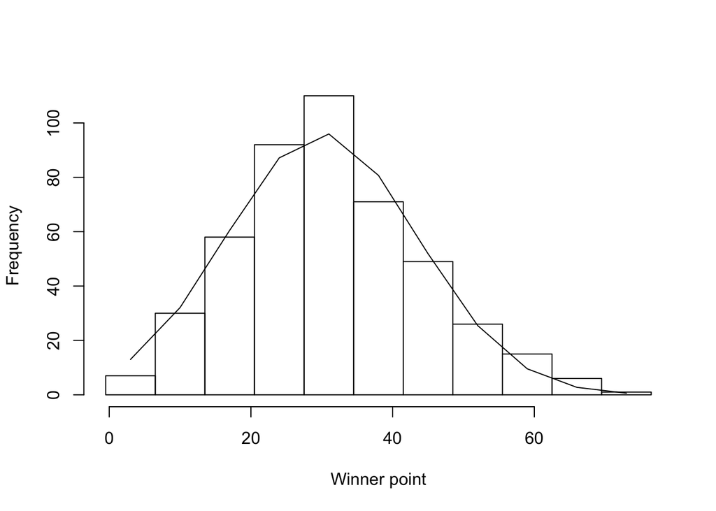

```r
#We use the fourth-spread of the sample to estimate the Gaussian standard deviation.
fit <- fit.gaussian(football$winner,bins,g.mean,g.sd)
options(digits=3)
h <- with(football,hist(winner, breaks = bins, xlab = "Winner point", main = ""))
lines(bin.mids,(fit$expected))
```

This histogram follows gaussian curve.

```r
d=fit$counts
e=fit$expected
RawRes=d-e #d-e
DRRes=sqrt(2+4*d)-sqrt(1+4*e) #DRR= sqrt(2+4d) − sqrt(1+4e)

options(digits = 3)
data.frame(Mid=bin.mids, Res=fit$residual, RawRes,DRRes)
```

```
##    Mid     Res RawRes  DRRes
## 1    3 -0.9606 -6.006 -1.805
## 2   10 -0.1879 -2.093 -0.329
## 3   17 -0.1628 -2.506 -0.292
## 4   24  0.2555  4.837  0.536
## 5   31  0.6926 14.049  1.407
## 6   38 -0.5580 -9.716 -1.085
## 7   45 -0.2031 -2.885 -0.370
## 8   52  0.0508  0.516  0.150
## 9   59  0.7806  5.437  1.609
## 10  66  0.7938  3.259  1.640
## 11  73  0.2253  0.400  0.605
```

#### (c) Use the R rootogram function to plot the residuals. Interpret the residuals in the display. Are there any extreme residuals? Is there any distinctive pattern in the residuals? Based on your comments, is a normal curve a good model for football scores of winning teams? If the normal curve is not a good model, explain why.

Hanging rootogram

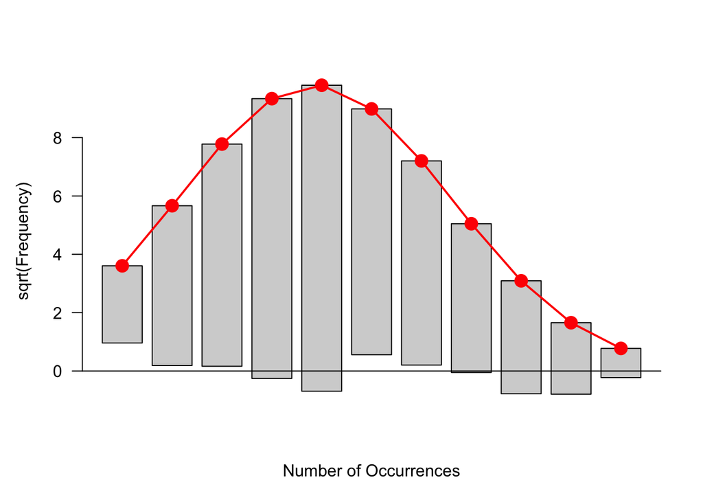

```r
rootogram(fit$counts, fit$expected)
```

We can see that the number of small points seems a bit low

hanging bars have been removed and bars are plotted with heights to interpret residuals

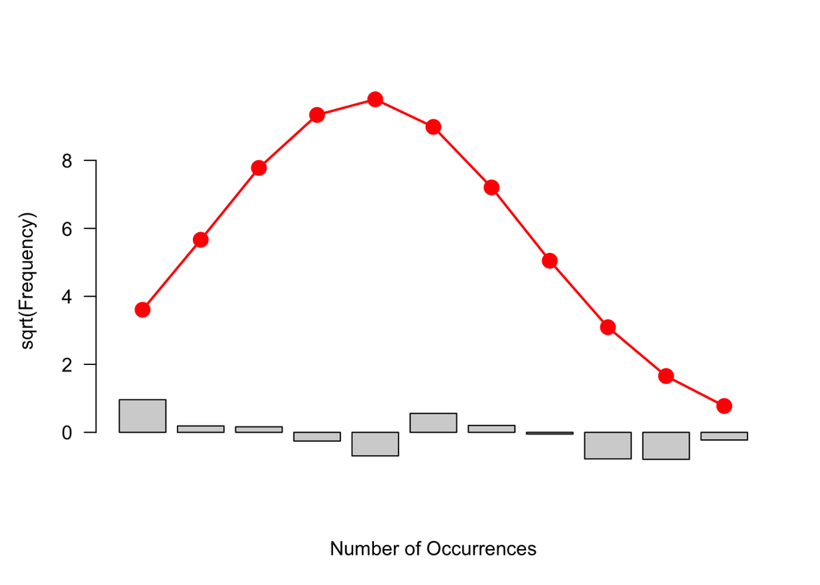

```r
rootogram(fit$counts, fit$expected, type="deviation")
```

Interpret the residuals:

Are there any extreme residuals? There are one possible residual which is -0.9606.

Is there any distinctive pattern in the residuals? I can see there are more positive residuals in the end.

Based on your comments, is a normal curve a good model for football scores of winning teams? If the normal curve is not a good model, explain why.

This is not normal becasue if the winner higher points, they would likely have positive risiduals.

### (d) For the team1 data, the data can be made more symmetric by applying a square root reexpression. Fit a Gaussian comparison curve to the root team1 data. (Bin the data using an appropriate set of bins, fit the Gaussian curve, and plot the residuals.) Comment on the goodness of the normal curve fit to the root data.

```r
sqrt.winner <- sqrt(football$winner)
head(sort(sqrt.winner))
```

```
## [1] 0.00 1.41 1.73 1.73 1.73 2.24
```

```r
bins<- seq(-0.05, 10, 0.9)
bin.mids <- (bins[-1] + bins[-length(bins)]) / 2

summary(bins)
```

```
##    Min. 1st Qu.  Median    Mean 3rd Qu.    Max.
##   -0.05    2.43    4.90    4.90    7.38    9.85
```

```r
g.mean=(lval(sqrt.winner)[2,3]+lval(sqrt.winner)[2,2])/2
g.mean
```

```
## [1] 5.41
```

```r
g.sd=(lval(sqrt.winner)[2,3]-lval(sqrt.winner)[2,2])/1.349
g.sd
```

```
## [1] 1.23
```

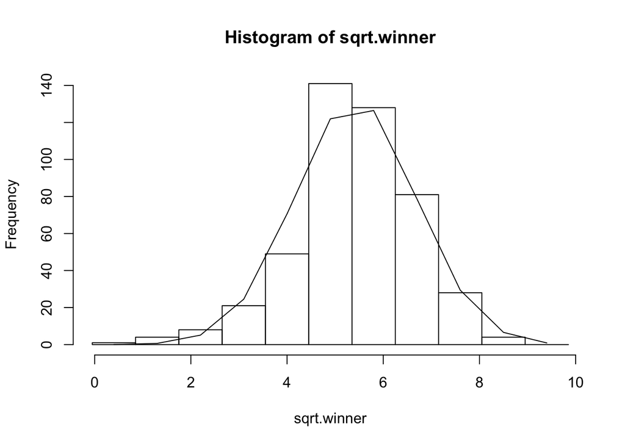

```r
#We use the fourth-spread of the sample to estimate the Gaussian standard deviation.
fit <- fit.gaussian(sqrt.winner,bins,g.mean,g.sd)
options(digits=3)
h <- hist(sqrt.winner, breaks = bins, plot =F)
plot(h)
lines(bin.mids,(fit$expected))
```

This histogram is more normal curve (symmetry)

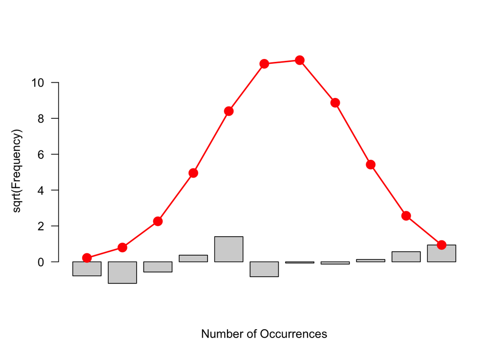

```r
rootogram(fit$counts, fit$expected, type="deviation")
```

Comment on the goodness of the normal curve fit to the root data:

### 2. Exploring Heights of Women

Use the EDA methods to fit a Gaussian comparison curve to the heights for a sample of college women who attend introductory statistics classes. The datafile studentdata in the LearnEDA package contains the data and the relevant variables are Height and Gender.

```r
head(studentdata)
```

```
##   Student Height Gender Shoes Number Dvds ToSleep WakeUp Haircut  Job
## 1       1     67 female    10      5   10    -2.5    5.5      60 30.0
## 2       2     64 female    20      7    5     1.5    8.0       0 20.0
## 3       3     61 female    12      2    6    -1.5    7.5      48  0.0
## 4       4     61 female     3      6   40     2.0    8.5      10  0.0
## 5       5     70   male     4      5    6     0.0    9.0      15 17.5
## 6       6     63 female    NA      3    5     1.0    8.5      25  0.0
##   Drink
## 1 water
## 2   pop
## 3  milk
## 4 water
## 5   pop
## 6 water
```

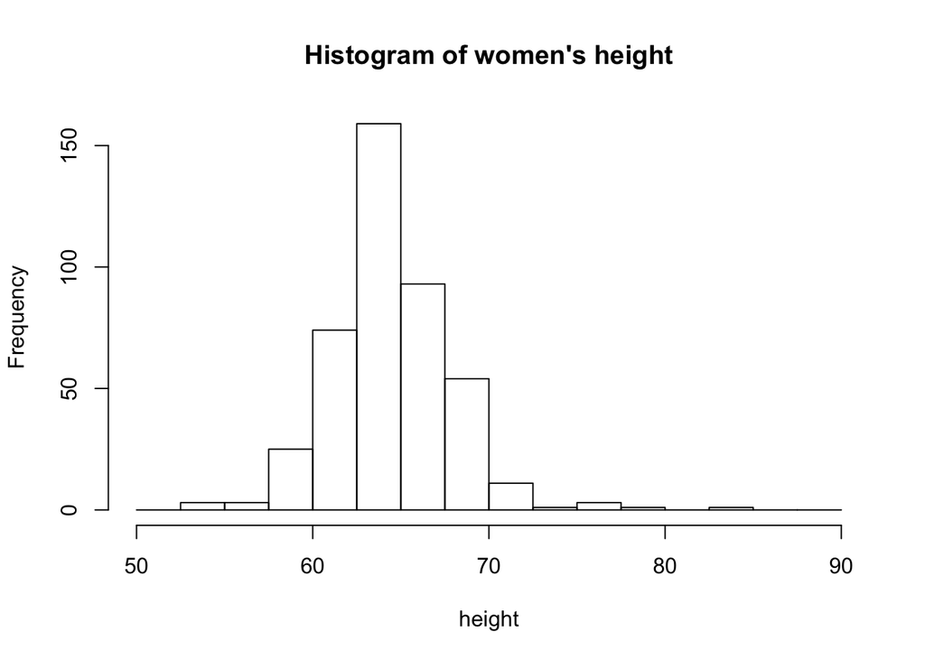

```r
height <- studentdata[which(studentdata[,3]=="female"),][,2]

#there are some missing data
height<-na.omit(height)

bins <-seq(50,90,2.5)

hist(height,breaks=bins,xlab="height", main = "Histogram of women's height")
```

There are an isolate data on the right and the histogram is rightskewed.

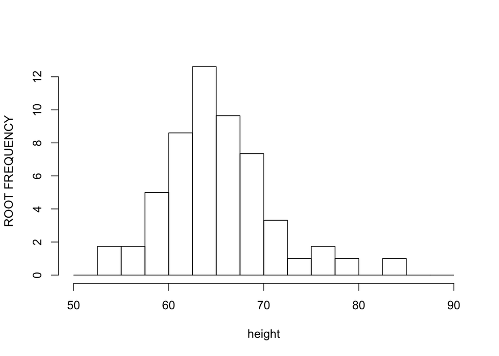

```r
new.h<-hist(height,breaks=bins,plot = F)
new.h$counts<-sqrt(new.h$counts)
plot(new.h,ylab = "ROOT FREQUENCY",main = "")
```

we can see that many of women’s height are distributed between 60 and 70.

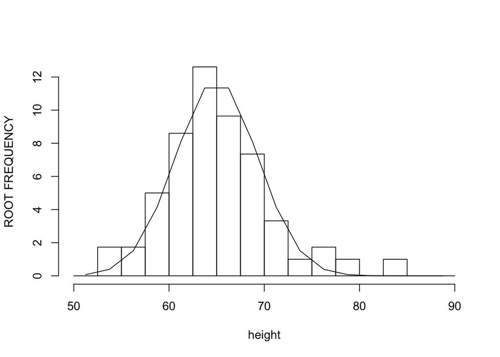

```r
#We use the fourth-spread of the sample to estimate the Gaussian standard deviation.


FU <-summary(height)[5]
FL <-summary(height)[2]
g.mean <-(FU+FL)/2
g.sd <- (FU-FL)/1.349

fit <- fit.gaussian(height,bins,g.mean,g.sd)
options(digits=3)
plot(new.h,ylab = "ROOT FREQUENCY",main = "")

bin.mids <- (bins[-1]+bins[-length(bins)])/2
lines(bin.mids,sqrt(fit$expected))
```

This histogram is more normal bell curve (symmetry) but there is a still right skewness.

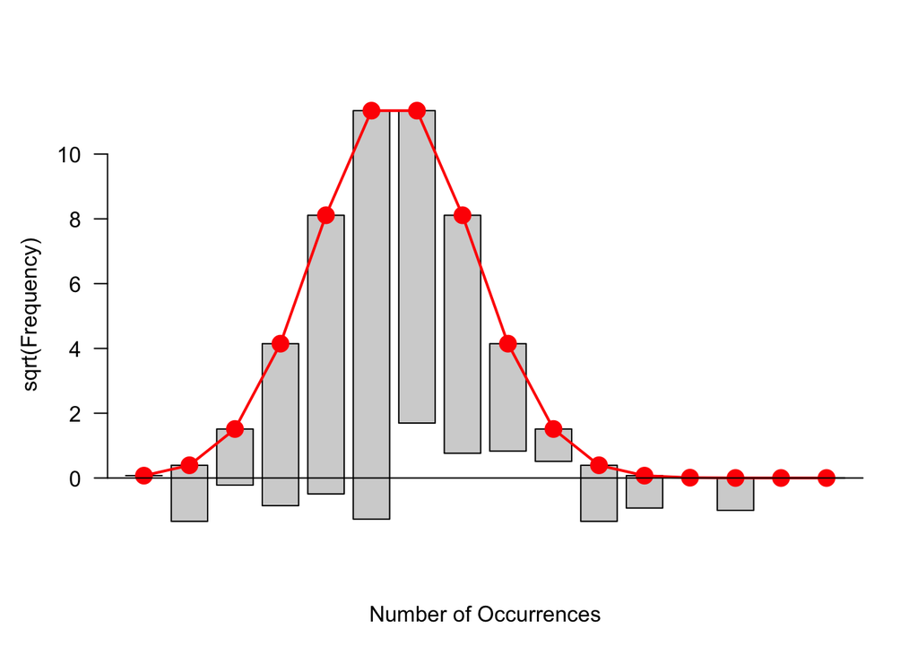

```r
rootogram(fit$counts, fit$expected)
```

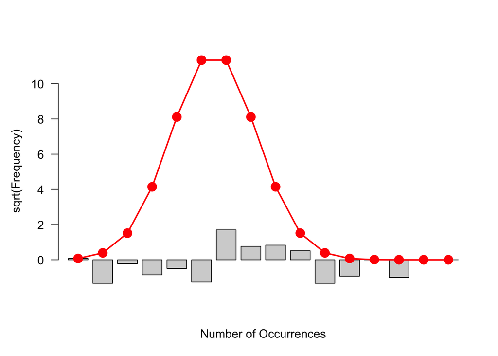

```r
rootogram(fit$counts, fit$expected, type="deviation")
```

```r
x <- aplpack::stem.leaf(c(fit$residual))
```

```
## 1 | 2: represents 1.2
##  leaf unit: 0.1
##             n: 16
##    1    -1. | 6
##         -1* |
##    4    -0. | 875
##    8    -0* | 0000
##   (2)    0* | 24
##    6     0. | 899
##    3     1* | 233
```

In the rootogram we were looking at the heights of the bars. In a hanging rootogram, we notice how the bars fall above or below the horizontal line at 0. Bars that fall below (above) the line correspond to positive (negative) residuals.

Are there any extreme residuals? We don’t see any extreme residuals here.

Is there any distinctive pattern in the residuals? I can see there are more positive residuals in the end.

Based on your comments, is a normal curve a good model for football scores of winning teams? If the normal curve is not a good model, explain why.

In conclusion, the normal curve is okay. fitting a Gaussian comparison curve to the heights gives not bad bell cureve in rootogram however, we could improve the histgram by taking power or smooting the roots counts.